# Predicting Life Expectancy - Summary Statistics

Molo Muli

5/22/2020

### Data Dimensions

The dataset dimension is `"[2,938 x 22]"`,2,938 rows and 22 columns. Out of these, Country, year and status columns are the only factors. All others are numeric. Below are all the column names of the dataset. More information about data present in the respective columns can be found [here](https://www.kaggle.com/kumarajarshi/life-expectancy-who/data).

```
##  [1] "Country"                      "Year"
##  [3] "Status"                       "LifeExpectancy"
##  [5] "AdultMortality"               "InfantDeaths"
##  [7] "Alcohol"                      "PercentageExpenditure"
##  [9] "HepatitisB"                   "Measles"
## [11] "BMI"                          "UnderFiveDeaths"
## [13] "Polio"                        "TotalExpenditure"
## [15] "Diphtheria"                   "HIVAIDS"
## [17] "GDP"                          "Population"
## [19] "Thinness1.19Years"            "Thinness5.9Years"
## [21] "IncomeCompositionofResources" "Schooling"
```

### Missing Values

The table below shows the count and corresponding missing percentage of missing values per column. Population is the most affected column accounting for 22% of its values missing.

| Column | Column Type | Missing Count | Missing (%) | Unique Rate |
| --- | --- | --- | --- | --- |
| Population | numeric | 652 | 22.19 | 0.78 |
| HepatitisB | integer | 553 | 18.82 | 0.03 |
| GDP | numeric | 448 | 15.25 | 0.85 |
| TotalExpenditure | numeric | 226 | 7.69 | 0.28 |
| Alcohol | numeric | 194 | 6.6 | 0.37 |
| IncomeCompositionofResources | numeric | 167 | 5.68 | 0.21 |
| Schooling | numeric | 163 | 5.55 | 0.06 |
| BMI | numeric | 34 | 1.16 | 0.21 |
| Thinness1.19Years | numeric | 34 | 1.16 | 0.07 |
| Thinness5.9Years | numeric | 34 | 1.16 | 0.07 |

[output cut: 4 more lines]

From the projects’ context, this is how missing values were handled:

> > As the data-sets were from WHO, we found no evident errors. Missing data was handled in R software by using Missmap command. The result indicated that most of the missing data was for population, Hepatitis B and GDP. The missing data were from less known countries like Vanuatu, Tonga, Togo, Cabo Verde etc. Finding all data for these countries was difficult and hence, it was decided that we exclude these countries from the final model data-set

### Outlier Mapping

| Column | Outlier Count | Outlier Ratio | Mean (With Outliers) | Mean (Without Outliers) |
| --- | --- | --- | --- | --- |
| HIVAIDS | 299 | 18.13 | 1.98 | 0.24 |
| Measles | 297 | 18.01 | 2224.49 | 87.93 |
| Population | 233 | 14.13 | 14653625.89 | 2859862.78 |
| UnderFiveDeaths | 222 | 13.46 | 44.22 | 10.24 |
| GDP | 208 | 12.61 | 5566.03 | 2175.68 |
| InfantDeaths | 199 | 12.07 | 32.55 | 8.31 |
| PercentageExpenditure | 187 | 11.34 | 698.97 | 226.32 |
| HepatitisB | 165 | 10.01 | 79.22 | 86.58 |
| Polio | 142 | 8.61 | 83.56 | 89.6 |
| Diphtheria | 134 | 8.13 | 84.16 | 89.75 |

[output cut: 9 more lines]

From the output we can further visualise showing the distribution with and without the outliers, in understanding distribution and the magnitude of the outliers given the ranges. The below plots shows variable columns wuth the highest outlier count. Depicting behaviour of the visuals with and without outliers.

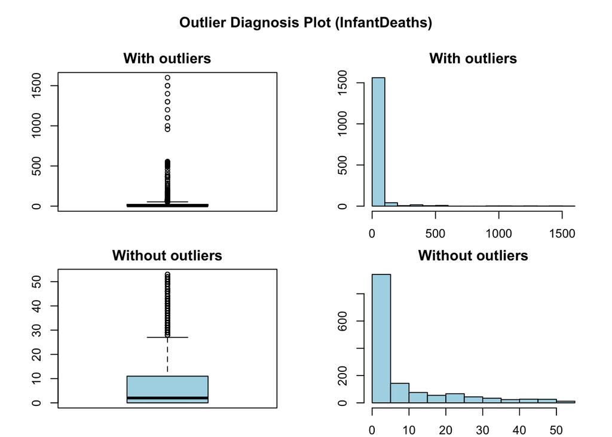

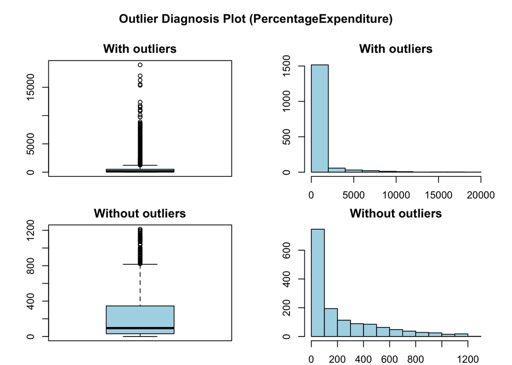

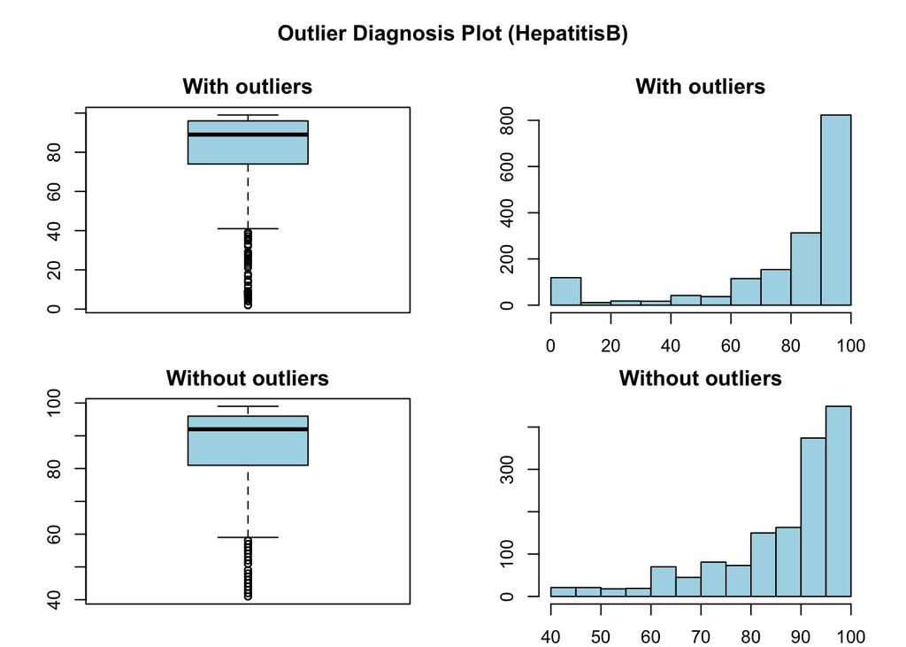

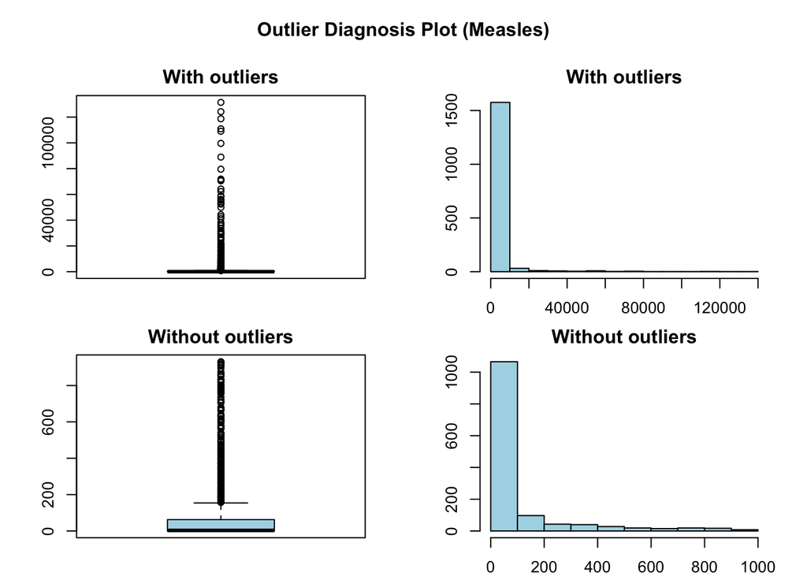

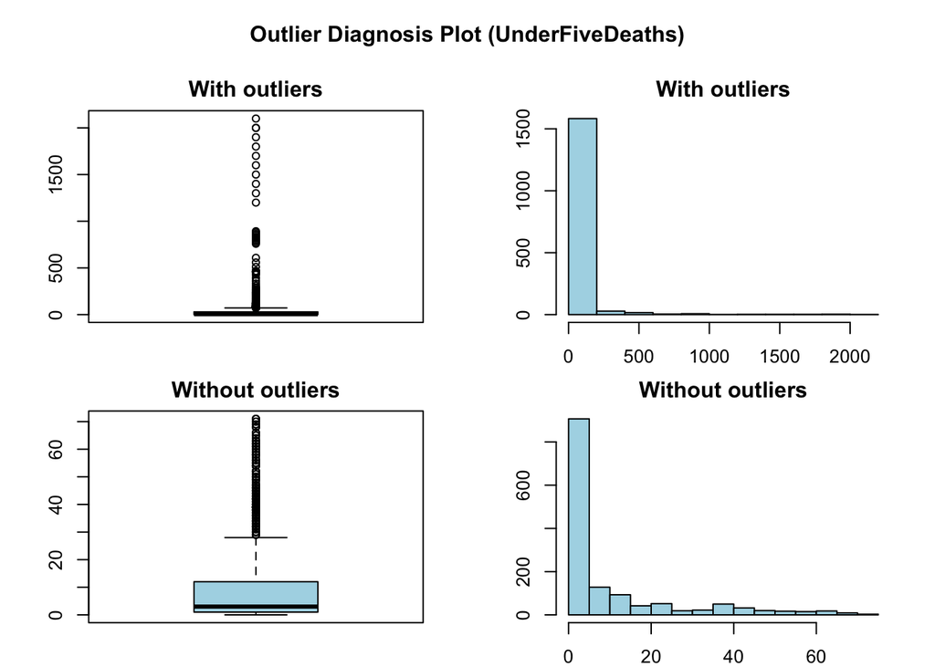

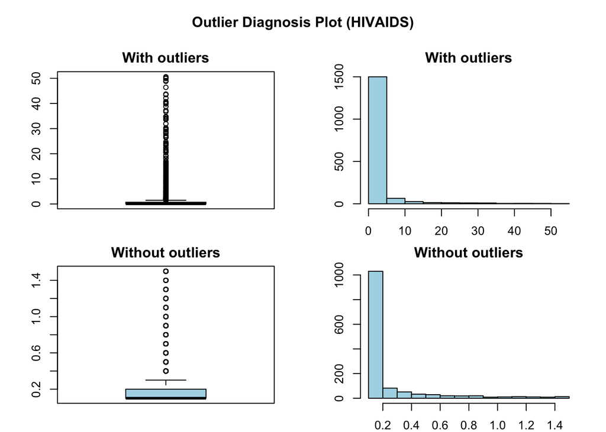

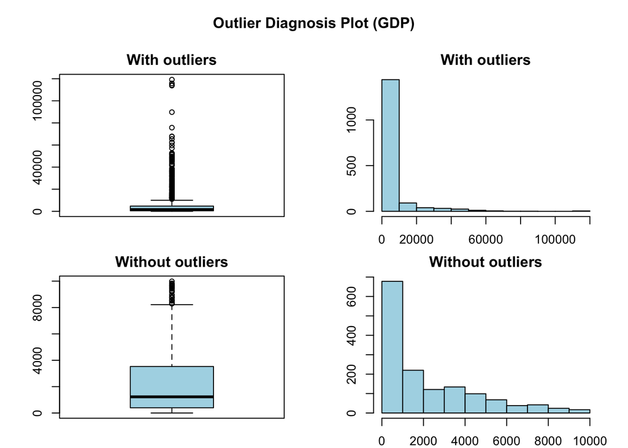

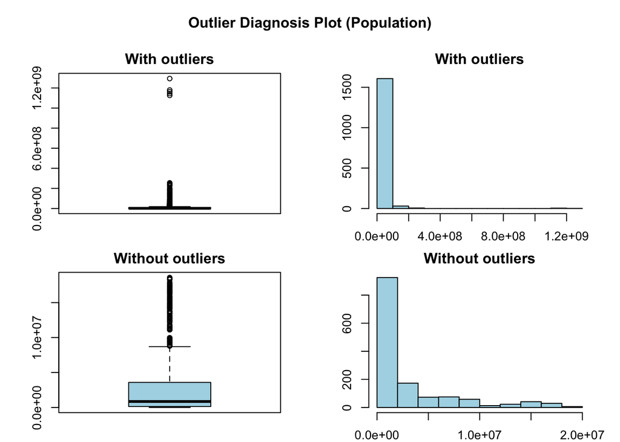

One of the ways of handling outliers in a data analysis process is to remove/filter them. However since earlier on we performed listwise deletion, I’ll also perform feature selection/extraction to then finally decide which columns to keep and select the appropriate range of outliers.